# BGGN-213, Lecture 8

Hands on with Principal Component Analysis (PCA)

Barry Grant < http://thegrantlab.org/bggn213/ >  
2018-12-07 (15:56:16 PST on Fri, Dec 07)

# Overview

In this hands-on session, we will examine some real life multivariate data in order to explain, in simple terms what PCA achieves. We will perform a principal component analysis of several different data sets and examine the results.

# 1. PCA of UK food data

Suppose that we are examining the [following data](https://bioboot.github.io/bggn213_f17/class-material/UK_foods.csv), from the UK’s ‘*Department for Environment, Food and Rural Affairs*’ (DEFRA), showing the consumption in grams (per person, per week) of 17 different types of foodstuff measured and averaged in the four countries of the United Kingdom in 1997.

[figure not shown]

|  | England | Wales | Scotland | N.Ireland |
| --- | --- | --- | --- | --- |
| Cheese | 105 | 103 | 103 | 66 |
| Carcass_meat | 245 | 227 | 242 | 267 |
| Other_meat | 685 | 803 | 750 | 586 |
| Fish | 147 | 160 | 122 | 93 |
| Fats_and_oils | 193 | 235 | 184 | 209 |
| Sugars | 156 | 175 | 147 | 139 |
| Fresh_potatoes | 720 | 874 | 566 | 1033 |
| Fresh_Veg | 253 | 265 | 171 | 143 |
| Other_Veg | 488 | 570 | 418 | 355 |
| Processed_potatoes | 198 | 203 | 220 | 187 |
| Processed_Veg | 360 | 365 | 337 | 334 |
| Fresh_fruit | 1102 | 1137 | 957 | 674 |
| Cereals | 1472 | 1582 | 1462 | 1494 |
| Beverages | 57 | 73 | 53 | 47 |
| Soft_drinks | 1374 | 1256 | 1572 | 1506 |
| Alcoholic_drinks | 375 | 475 | 458 | 135 |
| Confectionery | 54 | 64 | 62 | 41 |

We shall say that the 17 food types are the *variables* and the 4 countries are the *observations*. This would be equivalent to our *samples* and *genes* respectively from the lecture example (and indeed the second main example further below).

Lets read this [data](https://bioboot.github.io/bggn213_f17/class-material/UK_foods.csv) from the provided `UK_foods.csv` input file (note we placed this file in a `data` sub-directory within or working R studio *project* directory.

```r
x <- read.csv("data/UK_foods.csv")
```

> **Q1**. How many rows and columns are in your new data frame named `x`? What R functions could you use to answer this questions?

```r
## Complete the following code to find out how many rows and columns are in x?
___(x)
```

```
## [1] 17  5
```

**HINT**:**

You can use the **dim()** function, which returns the number of rows and columns or the **nrow()** and **ncol()** functions to return each separately, i.e. `dim(x); ncol(x); nrow(x)`

## Checking your data

It is always a good idea to examine your imported data to make sure it meets your expectations. At this stage we want to make sure that no odd things have happened during the importing phase that will come back to haunt us later.

For this task we can use the **View()** function to display all the data (in a new tab in RStudio) or the **head()** and **tail()** functions to print only a portion of the data (by default 6 rows from either the top or bottom of the dataset respectively).

> **Side-Note**: Never leave a **View()** function call uncommented in your Rmarkdown document as this is intended for interactive use and will stop the *Knit* rendering process when you go to *Knit* and generate HTML, PDF, MD etc. reports.

```r
## Preview the first 6 rows
___(x)
```

|  | X | England | Wales | Scotland | N.Ireland |
| --- | --- | --- | --- | --- | --- |
| 1 | Cheese | 105 | 103 | 103 | 66 |
| 2 | Carcass_meat | 245 | 227 | 242 | 267 |
| 3 | Other_meat | 685 | 803 | 750 | 586 |
| 4 | Fish | 147 | 160 | 122 | 93 |
| 5 | Fats_and_oils | 193 | 235 | 184 | 209 |
| 6 | Sugars | 156 | 175 | 147 | 139 |

Hmm, it looks like the row-names here were not set properly as we were expecting 4 columns (one for each of the 4 countries of the UK - not 5 as reported from the **dim()** function).

Here it appears that the row-names are incorrectly set as the first column of our `x` data frame (rather than set as proper row-names). This is very common error. Lets try to fix this up with the following code, which sets the **rownames()** to the first column and then removes the troublesome first column (with the **-1** column index):

```r
# Note how the minus indexing works
rownames(x) <- x[,1]
x <- x[,-1]
head(x)
```

|  | England | Wales | Scotland | N.Ireland |
| --- | --- | --- | --- | --- |
| Cheese | 105 | 103 | 103 | 66 |
| Carcass_meat | 245 | 227 | 242 | 267 |
| Other_meat | 685 | 803 | 750 | 586 |
| Fish | 147 | 160 | 122 | 93 |
| Fats_and_oils | 193 | 235 | 184 | 209 |
| Sugars | 156 | 175 | 147 | 139 |

This looks much better, now lets check the dimensions again:

```r
dim(x)
```

```
## [1] 17  4
```

> **Side-note**: An alternative approach to setting the correct row-names in this case would be to read the data filie again and this time set the `row.names` argument of **read.csv()** to be the first column (i.e. use argument setting `row.names=1`), see below:

```r
x <- read.csv("data/UK_foods.csv", row.names=1)
head(x)
```

|  | England | Wales | Scotland | N.Ireland |
| --- | --- | --- | --- | --- |
| Cheese | 105 | 103 | 103 | 66 |
| Carcass_meat | 245 | 227 | 242 | 267 |
| Other_meat | 685 | 803 | 750 | 586 |
| Fish | 147 | 160 | 122 | 93 |
| Fats_and_oils | 193 | 235 | 184 | 209 |
| Sugars | 156 | 175 | 147 | 139 |

> **Q2.** Which approach to solving the ‘row-names problem’ mentioned above do you prefer and why? Is one approach more robust than another under certain circumstances?

**HINT**:**

What happens if you run the first approach code block (i.e. the one with `x <- x[,-1]`), multiple times?

## Spotting major differences and trends

A cursory glance over the numbers in this table does not reveal much of anything. Indeed in general it is difficult to extract meaning in regard to major differences and trends from any given array of numbers. Generating regular bar-plots and various pairwise plots does not help too much either:

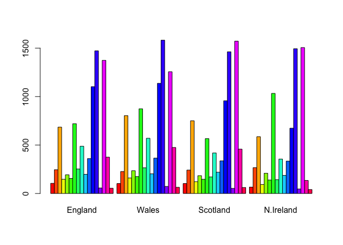

```r
barplot(as.matrix(x), beside=T, col=rainbow(nrow(x)))
```

> **Q3**: Changing what optional argument in the above **barplot()** function results in the following plot?

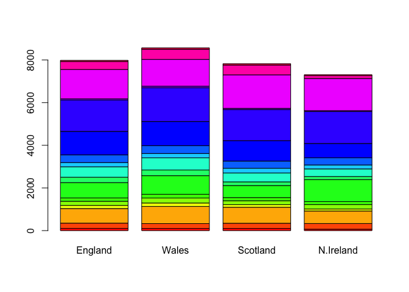

**HINT**:**

Try setting `beside=FALSE` in your **barplot()** code. Why would leaving this argument out have the same effect as setting it to FALSE? See the help page with `?barplot` for further details.

> **Q5**: Generating all pairwise plots may help somewhat. Can you make sense of the following code and resulting figure? What does it mean if a given point lies on the diagonal for a given plot?

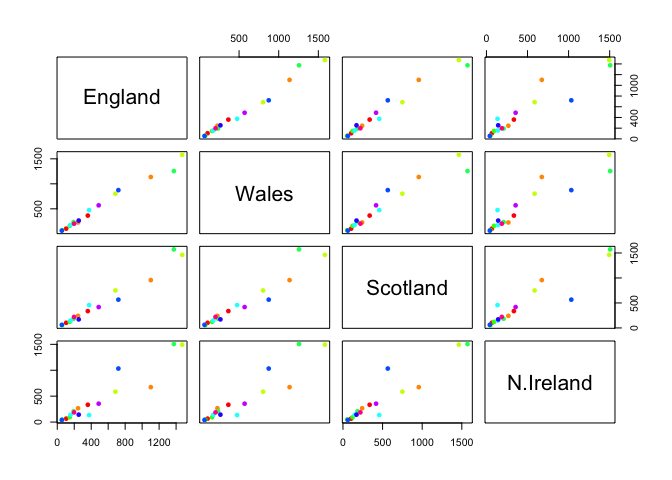

```r
pairs(x, col=rainbow(10), pch=16)
```

> **Even relatively small datasets can prove chalanging to interpertate** Given that it is quite difficult to make sense of even this relatively small data set. Hopefully, we can clearly see that a powerful analytical method is absolutely necessary if we wish to observe trends and patterns in larger datasets.

> **Q6**. What is the main differences between N. Ireland and the other countries of the UK in terms of this data-set?

## PCA to the rescue

We need some way of making sense of the above data. Are there any trends present which are not obvious from glancing at the array of numbers?

Traditionally, we would use a series of pairwise plots (i.e. bivariate scatter plots) and analyse these to try and determine any relationships between variables, however the number of such plots required for such a task is clearly too large even for this small dataset. Therefore, for large data sets, this is not feasible or fun.

PCA generalizes this idea and allows us to perform such an analysis simultaneously, for many variables. In our example here, we have 17 dimensional data for 4 countries. We can thus ‘imagine’ plotting the 4 coordinates representing the 4 countries in 17 dimensional space. If there is any correlation between the observations (the countries), this will be observed in the 17 dimensional space by the correlated points being clustered close together, though of course since we cannot visualize such a space, we are not able to see such clustering directly (see the lecture slides for a clear description and example of this).

To perform PCA in R there are actually lots of functions to chose from and many packages offer slick PCA implementations and useful graphing approaches. However here we will stick to the base R **prcomp()** function.

As we noted in the lecture portion of class, **prcomp()** expects the *observations* to be rows and the *variables* to be columns therefore we need to first transpose our data.frame matrix with the **t()** transpose function.

```r
# Use the prcomp() PCA function
pca <- ___( t(x) )
summary(pca)
```

```
## Importance of components:
##                             PC1      PC2      PC3       PC4
## Standard deviation     324.1502 212.7478 73.87622 4.189e-14
## Proportion of Variance   0.6744   0.2905  0.03503 0.000e+00
## Cumulative Proportion    0.6744   0.9650  1.00000 1.000e+00
```

The first task of PCA is to identify a new set of principal axes through the data. This is achieved by finding the directions of maximal variance through the coordinates in the 17 dimensional space. This is equivalent to obtaining the (least-squares) line of best fit through the plotted data where it has the largest spread. We call this new axis the first principal component (or PC1) of the data. The second best axis PC2, the third best PC3 etc.

The summary print-out above indicates that PC1 accounts for more than 67% of the sample variance, PC2 29% and PC3 3%. Collectively PC1 and PC2 together capture 96% of the original 17 dimensional variance. Thus these first two new principal axis (PC1 and PC2) represent useful ways to view and further investigate our data set. Lets start with a simple plot of PC1 vs PC2.

> **Q7**. Complete the code below to generate a plot of PC1 vs PC2. The second line adds text labels over the data points.

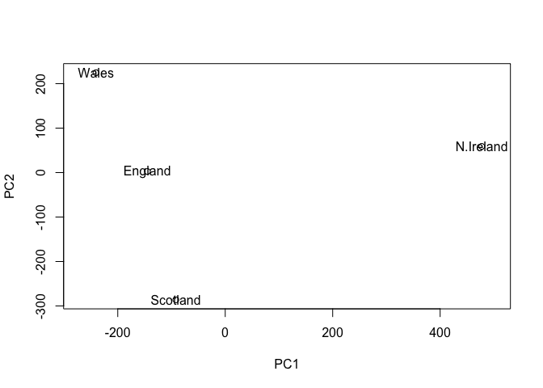

```r
# Plot PC1 vs PC2
plot(pca$x[___,___], pca$x[___,___], xlab="PC1", ylab="PC2", xlim=c(-270,500))
text(pca$x[,1], pca$x[,2], colnames(x))
```

> **Q8.** Customize your plot so that the colors of the country names match the colors in our UK and Ireland map and table at start of this document.

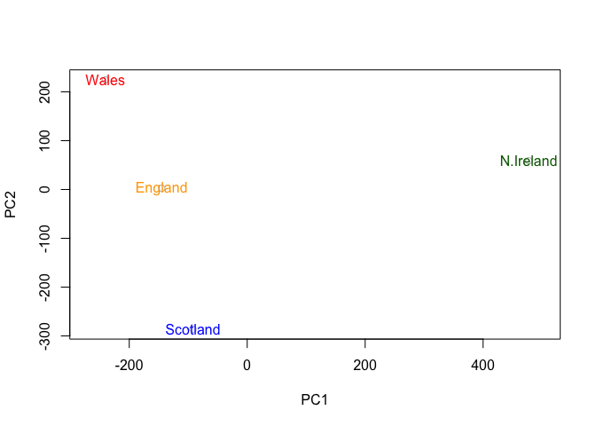

**HINT**:**

You can provide a color vector as input to the **text()** function just like you can with the **plot()** function itself.

Once the principal components have been obtained, we can use them to map the relationship between variables (i.e. countries) in therms of these major PCs (i.e. new axis that maximally describe the original data variance).

> In our food example here, the four 17 dimensional coordinates are projected down onto the two principal components to obtain the graph above.

In this case approximately 67% of the variance in the data is accounted for by the first principal component, and approximately 97% is accounted for in total by the first two principal components. In this case, we have therefore accounted for the vast majority of the variation in the data using only a two dimensional plot - **a dramatic reduction in dimensionality from seventeen dimensions to two**.

In practice, it is usually sufficient to include enough principal components so that somewhere in the region of 70% of the variation in the data is accounted for. Looking at the so-called scree plot can help in this regard. Ask Barry about this if you are unsure what we mean here.

> Below we can use the square of pca$sdev , which stands for “standard deviation”, to calculate how much variation in the original data each PC accounts for.

```r
v <- round( pca$sdev^2/sum(pca$sdev^2) * 100 )
v
```

```
## [1] 67 29  4  0
```

```r
## or the second row here...
z <- summary(pca)
z$importance
```

```
##                              PC1       PC2      PC3          PC4
## Standard deviation     324.15019 212.74780 73.87622 4.188568e-14
## Proportion of Variance   0.67444   0.29052  0.03503 0.000000e+00
## Cumulative Proportion    0.67444   0.96497  1.00000 1.000000e+00
```

This information can be summarized in a plot of the variances (eigenvalues) with respect to the principal component number (eigenvector number), which is given below.

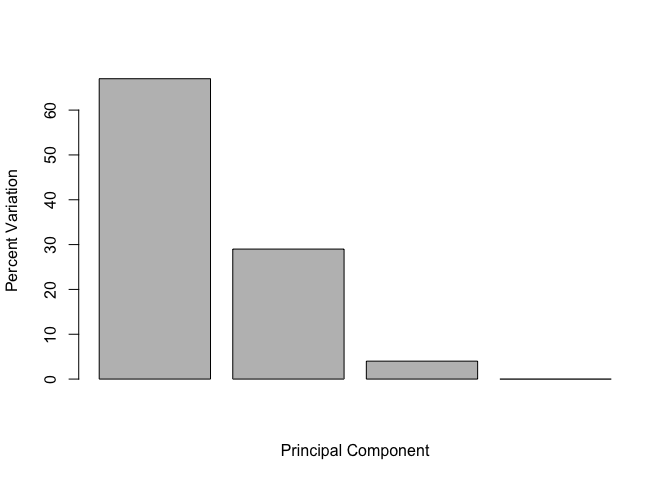

```r
barplot(v, xlab="Principal Component", ylab="Percent Variation")
```